# Data Science for Socioeconomists

OLS regression (part II)

Ulrich Fritsche

## How to choose an estimator: Unbiasedness and efficiency

- $\beta$ is the parameter in the population
- $b_1$ and $b_2$ are estimation results for $\hat{\beta}$ using different estimation techniques.

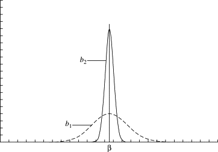

## How to choose an estimator: Unbiasedness and efficiency

- Which estimator do you prefer?
- The estimator with the narrow distribution gives a `more precise` estimate (precision is typically defined as the reciprocal of the variance of an estimator.)
- Aiming for precision is typically subsumed under the term `efficiency` in statistical literature

## Unbiasedness

Expected values $\mathbb{E}()$:
$$\mathbb{E}(\hat{\beta_0} + \hat{\beta_1} x_i) + \mathbb{E}(\varepsilon_i)$$

We assume $\mathbb{E}({\varepsilon_i}) = 0$ (i.e. unsystematic errors cancel out). That in turn implies:

## Unbiasedness, efficiency and the OLS estimator

$$\mathbb{E}(y_i) = \mathbb{E}(\text{systematic part}) = \mathbb{E}(\hat{\beta_0} + \hat{\beta_1} x_i)$$
Under certain conditions $\mathbb{E}(\hat{\beta_j}) = {\beta_j}$ (i.e. unbiasedness of coefficient estimates).

## Unbiasedness, efficiency and the OLS estimator

**Important**

We aim for **unbiased and efficient** (lowest possible variance/ highest precision) estimators .

Under certain conditions (we will dive deeper into this water in other courses), the OLS estimator is the `efficient` estimator in the class of linear unbiased estimators (the one with the lowest variance).

Remind: Under certain conditions we can call the OLS estimator `BLUE`: `B`est `L`inear `U`nbiased `E`stimator.

## The most important OLS assumptions in a nutshell

- The variable $x$ has explanatory power for $y$
- The relationship between $y$ and $x$ is linear or can be at least approximated as a linear relationship
- Parameters are the same for all observation pairs
- Residual series have a mean of zero, a constant variance and are normally distributed
- Residuals are not correlated with other residuals (e.g. $p$ lags apart)

## Hands-on example 1 (same example but with smarter handling)

```r
library(readr)
Advertising <- read_csv("./data/Advertising.csv", show_col_types = F)
attach(Advertising)
model <- lm(sales ~ TV)
summary(model)
```

```
Call:
lm(formula = sales ~ TV)

Residuals:
    Min      1Q  Median      3Q     Max
-8.3860 -1.9545 -0.1913  2.0671  7.2124

Coefficients:
            Estimate Std. Error t value Pr(>|t|)
(Intercept) 7.032594   0.457843   15.36   <2e-16 ***
TV          0.047537   0.002691   17.67   <2e-16 ***
---
Signif. codes:  0 '***' 0.001 '**' 0.01 '*' 0.05 '.' 0.1 ' ' 1

Residual standard error: 3.259 on 198 degrees of freedom
Multiple R-squared:  0.6119,    Adjusted R-squared:  0.6099
F-statistic: 312.1 on 1 and 198 DF,  p-value: < 2.2e-16
```

## Goodness of Fit (in-sample)

$$Var(y_i) = Var(\hat{y_i}) + Var(\varepsilon_i)$$
$$R^2 = \frac{Var(\hat{y_i})}{Var(y_i)} = \frac{Var(y_i)-Var(\varepsilon_i)}{Var(y_i)} = 1-\frac{Var(\varepsilon_i)}{Var(y_i)}$$

## Inference ($\beta_1$ as example)

- We can construct `confidence intervalls` for the coefficients
- The 95% confidence interval for $\beta_1$ approximately takes the form $\hat{\beta_1} \pm 2 \times SE(\hat{\beta_1})$
- That is, there is approximately a 95% chance that the interval $[\hat{\beta_1} − 2 \times SE(\hat{\beta_1}), \hat{\beta_1} + 2 \times SE(\hat{\beta_1}]$ contain the true value of $\beta_1$
- This in turn leads to the t-test

## t-Test ($\beta_1$ as example)

- $H_0$: There is no relationship between $y$ and $x$ ($\beta_1 = 0$).
- $H_1$: There is some relationship between $y$ and $x$ ($\beta_1 \neq 0$).

$$t = \frac{\hat{\beta_1} - \beta_1| H_0 = true}{SE(\hat{\beta_1})} = \frac{\hat{\beta_1} - 0}{SE(\hat{\beta_1})}$$

## Interpretation of coefficients as derivatives

- Population model (without subscripts) $y = \beta_0 + \beta_1 x + u$.
- What is $\frac{\partial y}{\partial x}$?
- It is given by $\beta_1$!

## Variable transformations changes the interpretation of coefficients

|  | **Level (x)** | **Log (x)** |
| --- | --- | --- |
| **Level (y)** | one unit increase in x changes y by $\beta_1$ | one percent increase in x changes y by $\beta_1 / 100$ units |
| **Log (y)** | one unit increase in x changes y by $100 \times \beta_1$ % | one percent increase in x changes y by $\beta_1$ % |

## Questions?

[figure not shown]